# SVM Regresion

Maria Lucia Guastoni

6/6/2021

# 1. Introducción

Con esta práctica se trata de ilustrar la regresión utilizando SVMs aplicando tanto la `Epsilon-SVR` como la `Nu-SVR`, así como otros modelos, sobre los datos del censo de California por grupos de bloques de vivienda con el objetivo de predecir los precios medios de la vivienda.

Las variables del conjunto de datos son:

- median_house_value
- median_income
- housing_median_age
- total_rooms
- total_bedrooms
- population
- households
- latitude
- longitude

Se recopilo información sobre las variables mencionadas usando todos los grupos de bloques en California del Censo de 1990. En esta muestra un grupo de bloques en promedio incluía 1425,5 personas que vivían en un área geográficamente compacta.

El trabajo está estructurado en 6 secciones. La presente, en donde se introduce y describe el problema. La segunda, en donde se cargan y limpian los datos. Una tercera sección en la que se realiza un análisis exploratorio de los datos, la cuarta en donde se preprocesan los datos para poder a continuación, en la sección cinco, evaluar diferentes modelos, y finalmente elegir el mejor entre todos.

# 2. Carga de los datos

En primer lugar se lee el archivo csv que contiene los datos:

```
Cantidad de filas y columnas del dataset:
```

```
[1] 20640     9
```

```
  median_house_value median_income housing_median_age total_rooms
1             452600        8.3252                 41         880
2             358500        8.3014                 21        7099
3             352100        7.2574                 52        1467
4             341300        5.6431                 52        1274
5             342200        3.8462                 52        1627
6             269700        4.0368                 52         919
  total_bedrooms population households latitude longitude
1            129        322        126    37.88   -122.23
2           1106       2401       1138    37.86   -122.22
3            190        496        177    37.85   -122.24
4            235        558        219    37.85   -122.25
5            280        565        259    37.85   -122.25
6            213        413        193    37.85   -122.25
```

El dataset contiene 20.640 observaciones y 9 variables.

# 3. Análisis exploratorio

En esta sección se analizan los datos para resumir sus principales características estadísticas.

Primero, se desea conocer el tipo de datos que contiene cada columna, y luego un resumen de sus principales medidas estadísticas:

```
'data.frame':   20640 obs. of  9 variables:
 $ median_house_value: num  452600 358500 352100 341300 342200 ...
 $ median_income     : num  8.33 8.3 7.26 5.64 3.85 ...
 $ housing_median_age: num  41 21 52 52 52 52 52 52 42 52 ...
 $ total_rooms       : num  880 7099 1467 1274 1627 ...
 $ total_bedrooms    : num  129 1106 190 235 280 ...
 $ population        : num  322 2401 496 558 565 ...
 $ households        : num  126 1138 177 219 259 ...
 $ latitude          : num  37.9 37.9 37.9 37.9 37.9 ...
 $ longitude         : num  -122 -122 -122 -122 -122 ...
```

```
 median_house_value median_income     housing_median_age  total_rooms
 Min.   : 14999     Min.   : 0.4999   Min.   : 1.00      Min.   :    2
 1st Qu.:119600     1st Qu.: 2.5634   1st Qu.:18.00      1st Qu.: 1448
 Median :179700     Median : 3.5348   Median :29.00      Median : 2127
 Mean   :206856     Mean   : 3.8707   Mean   :28.64      Mean   : 2636
 3rd Qu.:264725     3rd Qu.: 4.7432   3rd Qu.:37.00      3rd Qu.: 3148
 Max.   :500001     Max.   :15.0001   Max.   :52.00      Max.   :39320
 total_bedrooms     population      households        latitude
 Min.   :   1.0   Min.   :    3   Min.   :   1.0   Min.   :32.54
 1st Qu.: 295.0   1st Qu.:  787   1st Qu.: 280.0   1st Qu.:33.93
 Median : 435.0   Median : 1166   Median : 409.0   Median :34.26
 Mean   : 537.9   Mean   : 1425   Mean   : 499.5   Mean   :35.63
 3rd Qu.: 647.0   3rd Qu.: 1725   3rd Qu.: 605.0   3rd Qu.:37.71
 Max.   :6445.0   Max.   :35682   Max.   :6082.0   Max.   :41.95
   longitude
 Min.   :-124.3
 1st Qu.:-121.8
 Median :-118.5
 Mean   :-119.6
 3rd Qu.:-118.0
 Max.   :-114.3
```

También se desea conocer si existen valores faltantes:

```
median_house_value      median_income housing_median_age        total_rooms
                 0                  0                  0                  0
    total_bedrooms         population         households           latitude
                 0                  0                  0                  0
         longitude
                 0
```

Se confirma que no faltan valores en ninguna de las variables.

Se elimnan las dos variables geográficas, que no serán útiles para el análisis que en este trabajo se llevará a cabo.

También es necesario asegurarse que no existen variables altamente correlacionadas, con el fin de evitar multicolinealidad. Para ello se calcula la matriz de correlaciones.

|  | median_house_value | median_income | housing_median_age | total_rooms | total_bedrooms | population | households |
| --- | --- | --- | --- | --- | --- | --- | --- |
| median_house_value | 1 | 0.688 | 0.106 | 0.134 | 0.051 | -0.025 | 0.066 |
| median_income |  | 1 | -0.119 | 0.198 | -0.008 | 0.005 | 0.013 |
| housing_median_age |  |  | 1 | -0.361 | -0.32 | -0.296 | -0.303 |
| total_rooms |  |  |  | 1 | 0.93 | 0.857 | 0.918 |
| total_bedrooms |  |  |  |  | 1 | 0.878 | 0.98 |
| population |  |  |  |  |  | 1 | 0.907 |
| households |  |  |  |  |  |  | 1 |

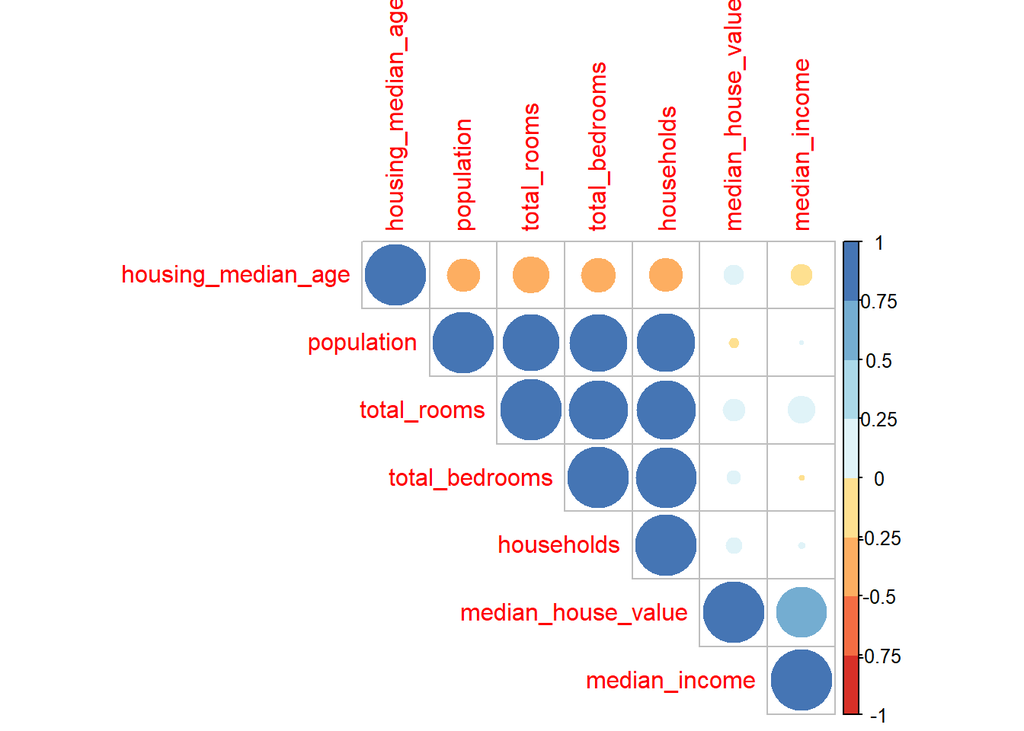

Como se observa de la tabla y el gráfico, la correlación entre las variables “total_rooms”, “total_bedrooms”, “population” y “households” es muy alta, lo cual tiene sentido, puesto que una casa con más dormitorios (total bedrooms) tendrá más habitaciones (total rooms) que una con menos dormitorios. También los bloques en donde existe más población (population) tiene sentido que tengan más hogares (households), así como más habitaciones.

También se ve que la “edad” media de la casa está correlacionada negativamente con la población, lo cual significa que en zonas donde las casas son más antiguas, hay menos población, y por lo tanto, los barrios con viviendas más nuevas están más pobladas. Por otro lado, la antiguedad de la casa está correlacionada negativamente con la cantidad de habitaciones y de dormitorios de la casa, así como con la cantidad de hogares. Es decir, los bloques de la muestra con viviendas con más habitaciones y más dormitorios, tienden a ser más nuevas; y en los bloques donde hay mayor cantidad de hogares las viviendas tienden a ser más nuevas.

La cantidad de habitaciones de una casa posee un cierto grado de correlación con el nivel de ingresos del bloque. Ante mayores niveles de ingreso, mayor cantidad de habitaciones en la vivienda. En menor grado, existe también una relación negativa entre el nivel de ingresos y la antiguedad de la casa.

Se sigue con un análisis gráfico de cada una de las variables.

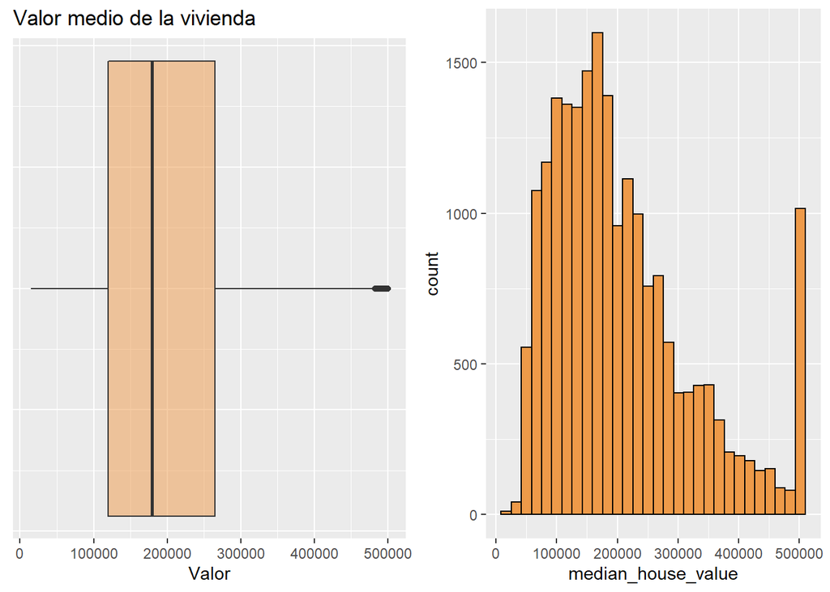

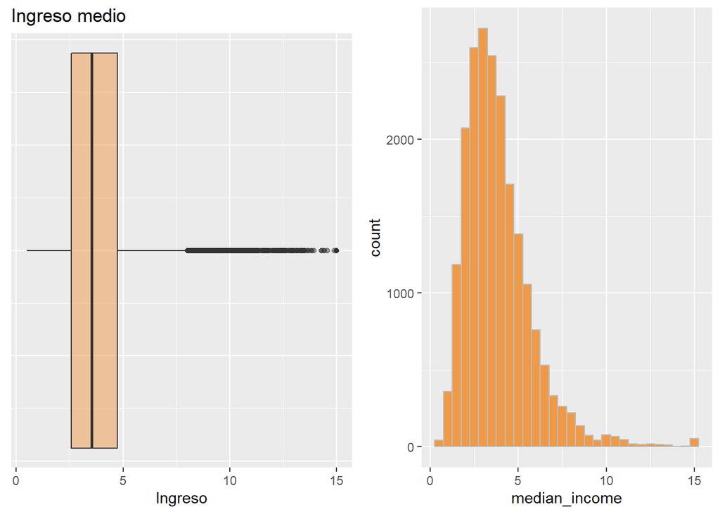

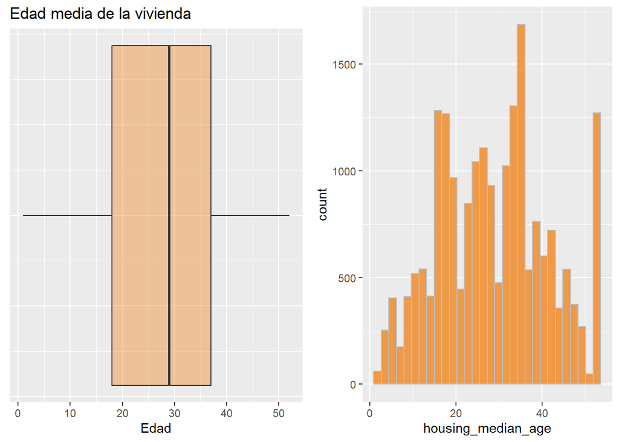

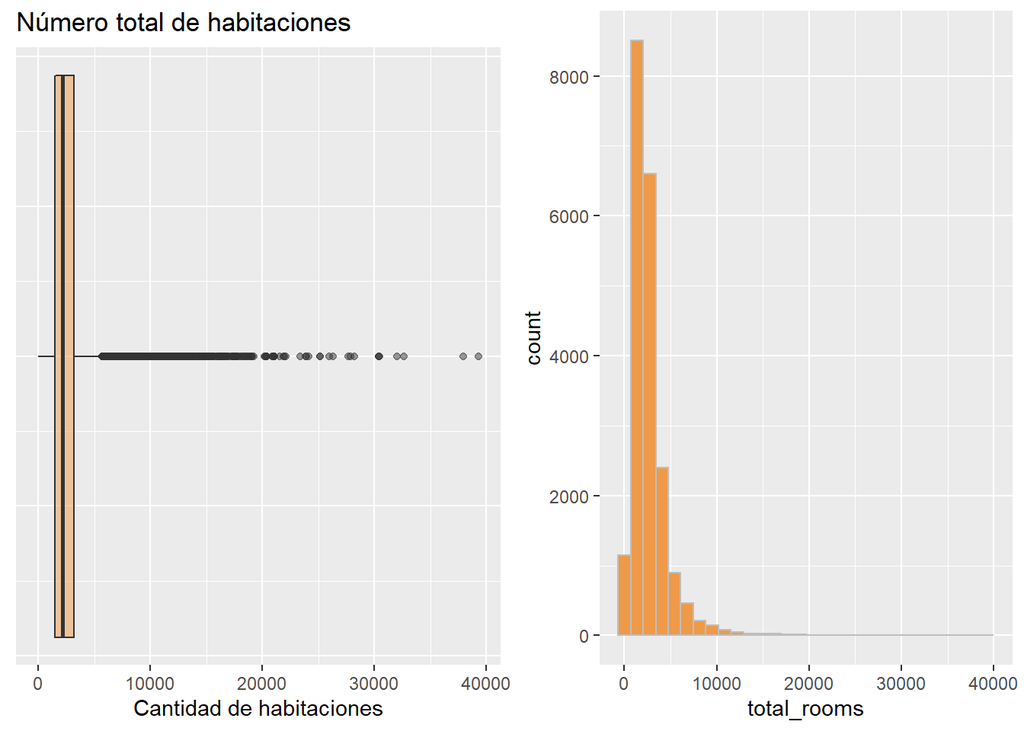

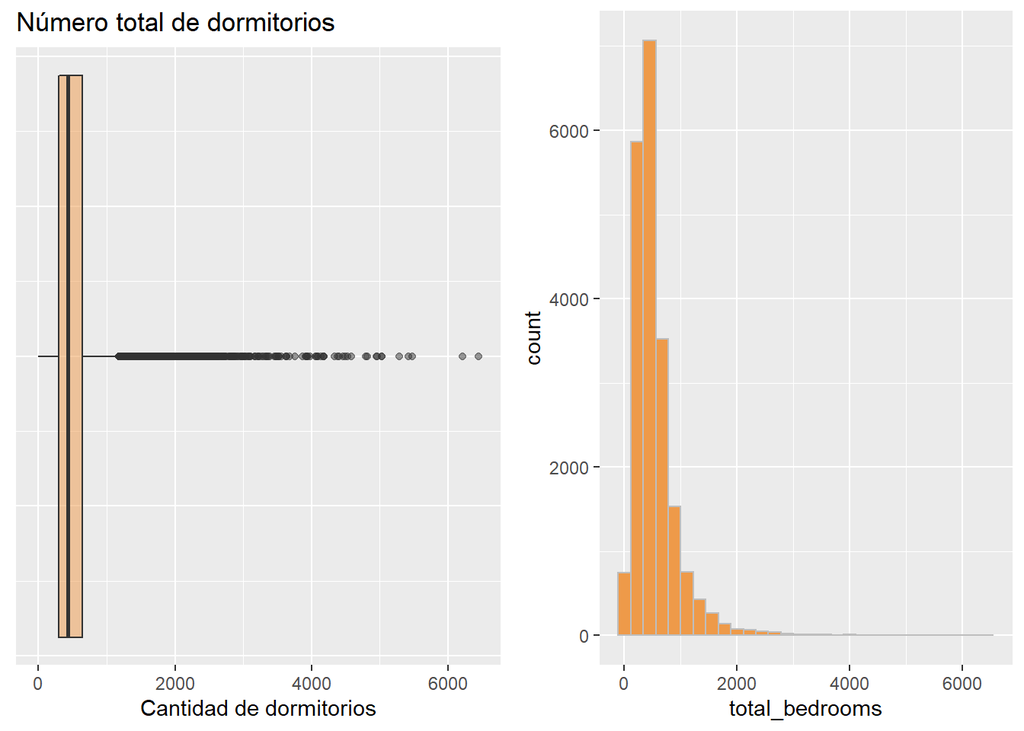

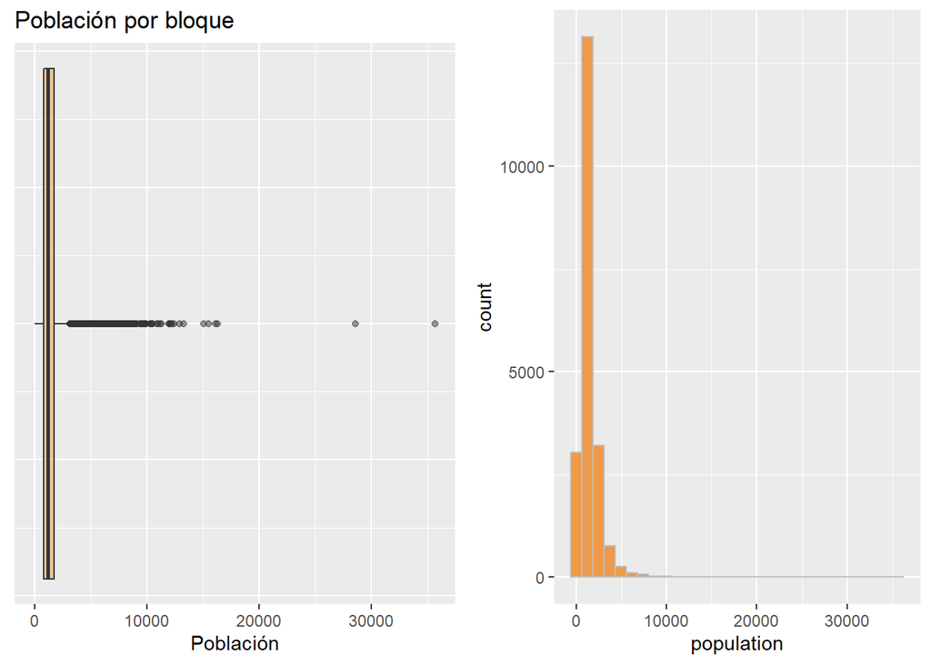

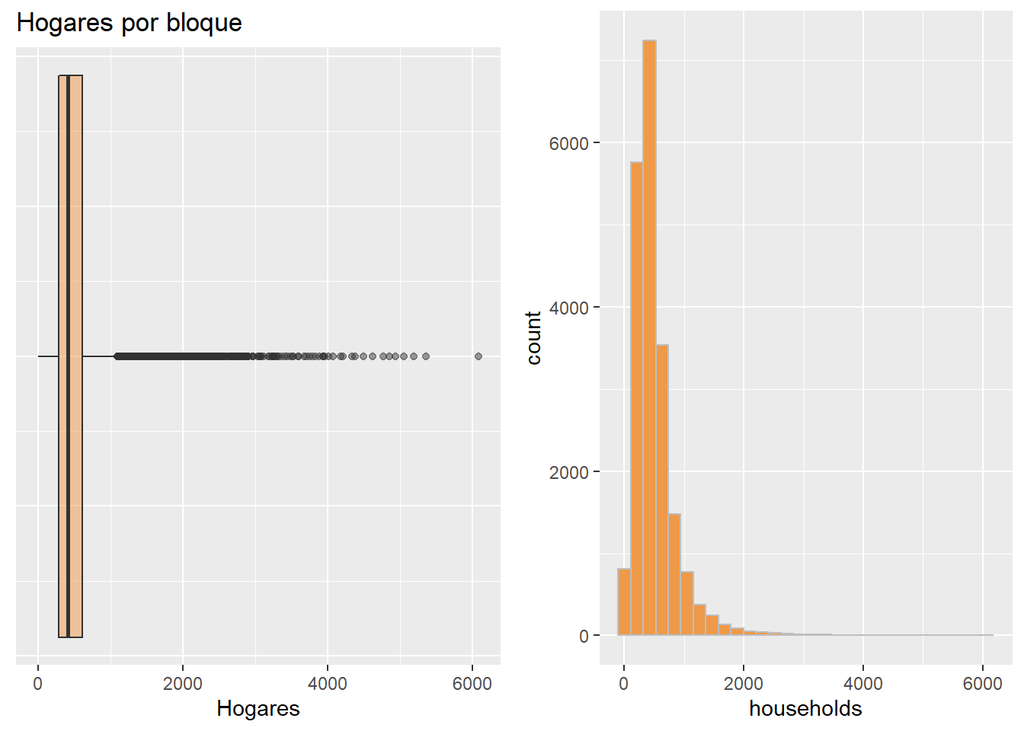

De los gráficos se observa que las variables habitaciones, dormitorios, población y hogares tienen valores extremos. Justamente estas son las cuatro variables que están altamente correlacionadas, debido a que una mayor población conlleva mayores valores de las otras tres variables. Es probable que se trate de las zonas más pobladas de California, como ciertos barrios o ciudades, como por ejemplo Los Ángeles, la segunda ciudad más poblada de todo Estados Unidos, con una densidad poblacional en 2016 de 8.484 personas por milla cuadrada.

Se calcula la cantidad de casos en los que la población es mayor a 5.000, 10.000 y 15.000 personas por bloque

Cantidad de observaciones según nivel de población:

| población_mayor_a | count |
| --- | --- |
| 5000 | 305 |
| 10000 | 23 |
| 15000 | 6 |

La tabla muestra que existen 305 observaciones o bloques con una población mayor a 5.000, 23 a 10.000 y 6 mayor a 15.000. Se decide eliminar las observaciones a partir de 10.000 personas por bloque, de modo de eliminar las pocas observaciones con valores altamente alejados de la media, pero tampoco subrepresentar o excluir del análisis las áreas más densamente pobladas.

Nos quedamos entonces con 20617 observaciones, un 99.89% de las observaciones totales.

|  | Valor medio > 480.000 | Todos los valores |
| --- | --- | --- |
| median_house_value | 499132.68 | 206846.96 |
| median_income | 7.61 | 3.87 |
| housing_median_age | 33.83 | 28.66 |
| total_rooms | 2932.61 | 2611.19 |
| total_bedrooms | 502.15 | 533.78 |
| population | 1113.16 | 1411.43 |
| households | 466.59 | 495.66 |

Dado que esto tiene sentido, no se consideran estas observaciones como outliers. Representan las viviendas y zonas más exclusivas de California, que son pocas, y por lo tanto no serán eliminadas.

# 4. Preprocesamiento de los datos

### 4.1 Modelo

A continuación se definen las variables que se desean incluir en el modelo a estimar en el próximo apartado.

```
  log_median_house_value median_income median_income_2 median_income_3
1               13.02276        8.3252        69.30896       577.01091
2               12.78968        8.3014        68.91324       572.07639
3               12.77167        7.2574        52.66985       382.24620
4               12.74052        5.6431        31.84458       179.70214
5               12.74315        3.8462        14.79325        56.89782
6               12.50507        4.0368        16.29575        65.78270
  log_housing_median_age log_rooms_pop log_bedrooms_pop log_pop_househ
1               3.713572     1.0053704       -0.9147391      0.9382696
2               3.044522     1.0840686       -0.7751354      0.7466130
3               3.951244     1.0843989       -0.9595519      1.0304262
4               3.951244     0.8255579       -0.8647734      0.9352872
5               3.951244     1.0576674       -0.7020361      0.7799977
6               3.951244     0.7998385       -0.6621554      0.7607574
  log_households
1       4.836282
2       7.037028
3       5.176150
4       5.389072
5       5.556828
6       5.262690
```

### 4.2 Train y Test sets

```
Dimensiones data_train:
```

```
[1] 14435     9
```

```
Dimensiones data_test:
```

```
[1] 6182    9
```

# 5. Implementación de modelos

## 5.1 Regresión Lineal

Con datos sin normalizar:

```
Call:
lm(formula = .outcome ~ ., data = dat)

Residuals:
    Min      1Q  Median      3Q     Max
-3.1499 -0.2117  0.0023  0.2060  2.6565

Coefficients:
                        Estimate Std. Error t value Pr(>|t|)
(Intercept)            11.522680   0.050571  227.85   <2e-16 ***
median_income           0.489880   0.012615   38.83   <2e-16 ***
median_income_2        -0.018082   0.002117   -8.54   <2e-16 ***
median_income_3        -0.000115   0.000102   -1.13     0.26
log_housing_median_age  0.153103   0.005634   27.18   <2e-16 ***
log_rooms_pop          -0.865919   0.018532  -46.73   <2e-16 ***
log_bedrooms_pop        0.817339   0.025391   32.19   <2e-16 ***
log_pop_househ         -0.397330   0.023319  -17.04   <2e-16 ***
log_households          0.042473   0.004414    9.62   <2e-16 ***
---
Signif. codes:  0 '***' 0.001 '**' 0.01 '*' 0.05 '.' 0.1 ' ' 1

Residual standard error: 0.36 on 14426 degrees of freedom
Multiple R-squared:  0.604, Adjusted R-squared:  0.604
F-statistic: 2.75e+03 on 8 and 14426 DF,  p-value: <2e-16
```

El modelo de regresión lineal con los datos no normalizados tiene un R2 ajustado de 0.604. Todas las variables excepto median_income^3 son estadísticamente significativas.

Con datos normalizados:

Primero se normalizan los datos, y luego se estima el modelo:

```
Call:
lm(formula = .outcome ~ ., data = dat)

Residuals:
    Min      1Q  Median      3Q     Max
-3.1499 -0.2117  0.0023  0.2060  2.6565

Coefficients:
                       Estimate Std. Error t value Pr(>|t|)
(Intercept)             11.1082     0.1631   68.10   <2e-16 ***
median_income            7.1034     0.1829   38.83   <2e-16 ***
median_income_2         -4.0639     0.4758   -8.54   <2e-16 ***
median_income_3         -0.3889     0.3454   -1.13     0.26
log_housing_median_age   0.6049     0.0223   27.18   <2e-16 ***
log_rooms_pop           -8.6455     0.1850  -46.73   <2e-16 ***
log_bedrooms_pop         8.1413     0.2529   32.19   <2e-16 ***
log_pop_househ          -2.9773     0.1747  -17.04   <2e-16 ***
log_households           0.3584     0.0372    9.62   <2e-16 ***
---
Signif. codes:  0 '***' 0.001 '**' 0.01 '*' 0.05 '.' 0.1 ' ' 1

Residual standard error: 0.36 on 14426 degrees of freedom
Multiple R-squared:  0.604, Adjusted R-squared:  0.604
F-statistic: 2.75e+03 on 8 and 14426 DF,  p-value: <2e-16
```

Las métricas son idénticas a los del modelo anterior. Naturalmente, los coeficientes toman otros valores puesto que las variables están normalizadas, la misma variable es no estadísticamente significativa.

Los residuos pueden verse en el siguiente gráfico:

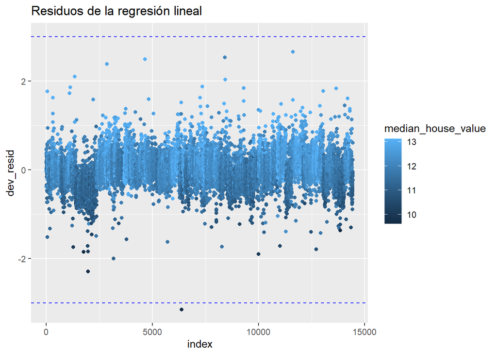

Puede verse que sólo una observación está a más de -3 desvíos standard.

## 5.2 Árboles de decisión: XG Boost

Extreme Gradient Boosting -XGBoost- es un algoritmo de aprendizaje automático basado en ensambles de árboles de decisión, que utiliza el descenso por el gradiente para minimizar los errores. Adicionalmente, al implementar paralelamente el proceso de construcción de los árboles, entre otros aspectos, se optimizan considerablemente los tiempos de ejecución.

A continuación deben tunearse los parámetros de este modelo, que serán brevemente descritos a continuación:

nrounds:

controla el número máximo de iteraciones. En el caso de clasificación, es similar al número de árboles que deben crecer.

max_depth:

controla la profundidad máxima de los árboles. Los árboles más profundos tienen más nodos terminales y se ajustan a más datos. La convergencia también requiere menos árboles si se los hace crecer en profundidad. Sin embargo, si los árboles son demasiado profundos se estará utilizando mucha información de los primeros árboles y los árboles finales del algoritmo tendrán menos importancia en la función de pérdida.

eta:

es el parámetro de aprendizaje. Controla la cantidad de información de un nuevo árbol que se utilizará en el Boosting. Este parámetro debe ser mayor que 0 y estar limitado a 1. Si es cercano a cero se utiliza sólo una pequeña parte de la información de cada nuevo árbol. Si se establece eta = 1 se utiliza toda la información del nuevo árbol. Los valores grandes de eta dan como resultado una convergencia más rápida pero más problemas de sobreajuste. Los valores pequeños pueden necesitar muchos árboles para converger.

gamma:

parámetro de regularización, o reducción de la pérdida mínima para crear una nueva división del árbol.

colsample_bytree:

es el porcentaje de variables que se seleccionan aleatoriamente para hacer crecer cada nuevo nodo de un árbol. Si se utilizan todas las variables, el algoritmo necesita menos árboles para converger, pero si se selecciona un subset de las variables se obtendrán modelos más robustos al sobreajuste.

subsample:

proporción de submuestreo de las instancias de entrenamiento. Si se establece en 0,5, XGBoost muestreará aleatoriamente la mitad de los datos de entrenamiento antes de hacer crecer los árboles, lo que evitará el sobreajuste. El submuestreo se realizará una vez en cada iteración de boosting. La diferencia con colsample_bytree es que este selecciona columnas o features, mientras que subset samplea observaciones.

min_child_weight: suma mínima de peso de instancia (hessiaan) necesaria en un hijo. Si el paso de partición del árbol da como resultado un nodo hoja con la suma del peso de la instancia menor que min_child_weight, entonces el proceso de construcción renunciará a seguir partiendo. En la tarea de regresión lineal, esto corresponde simplemente al número mínimo de instancias necesarias para estar en cada nodo. Cuanto mayor sea min_child_weight, más conservador será el algoritmo.

La mejor combinación de parámetros es:

```
    nrounds max_depth  eta gamma colsample_bytree min_child_weight subsample
320     300         6 0.05   0.2             0.75              0.5       0.5
```

El mejor modelo es aquel con los parámetros arriba indicados.

A continuación se predice utilizando el set de test, y se visualiza la recta estimada junto con los valores de la variable target reales/observados:

```
    RMSE Rsquared      MAE
    0.33     0.67     0.24
```

El RMSE es de 0.33 y el R2 de 0.67.

Gráficamente:

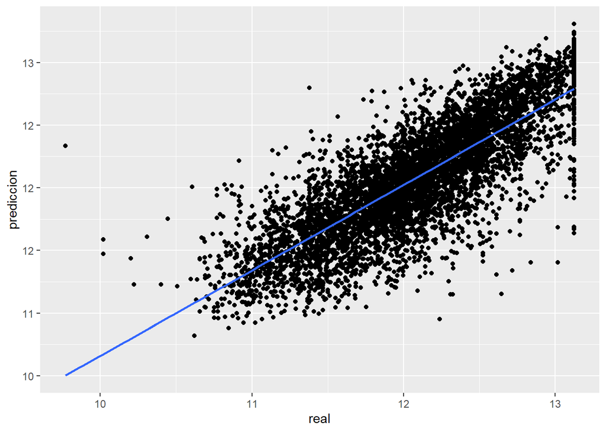

También se grafican los residuos:

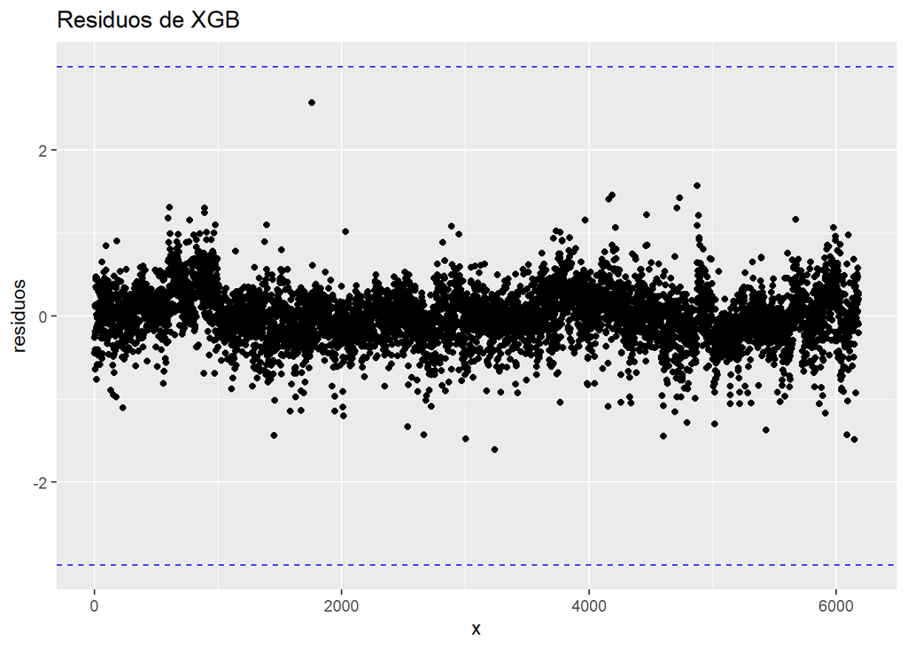

Dado que XGB no estima coeficientes, solo se añadirán el resto de los datos a la tabla de resultados.

## 5.3 SVM

En este apartado se estiman dos tipos de SVM: Epsilon y Nu. Además, para cada uno, se evalúan tres tipos de kernels: radial, lineal y polinomial.

En ν-SVR, el parámetro ν se utiliza para determinar la proporción del número de vectores de soporte que se desea mantener en la solución con respecto al número total de muestras en el conjunto de datos.

Por otro lado, en ϵ-SVR no se tiene control sobre cuántos vectores del conjunto de datos se convierten en vectores de soporte. No obstante, se tiene control sobre cuánto error se permite que tenga el modelo, y todo lo que supere el ϵ especificado será penalizado en proporción a C, que es el parámetro de regularización.

### 5.3.1 Epsilon - SVR

El valor de ϵ define un margen de tolerancia en el que no se penalizan los errores. Cuanto mayor sea ϵ, mayores serán los errores que admita la solución.

#### 5.3.1.1 Kernel Radial

Se estima el modelo y luego se realiza la predicción

```
Call:
svm(formula = log_median_house_value ~ ., data = data_train, type = "eps-regression",
    kernel = "radial", trControl = trainControl(method = "cv", number = 10,
        allowParallel = TRUE), tuneGrid = epsilonSVRGrid, metric = "RMSE")


Parameters:
   SVM-Type:  eps-regression
 SVM-Kernel:  radial
       cost:  1
      gamma:  0.12
    epsilon:  0.1


Number of Support Vectors:  11790
```

Gráficamente:

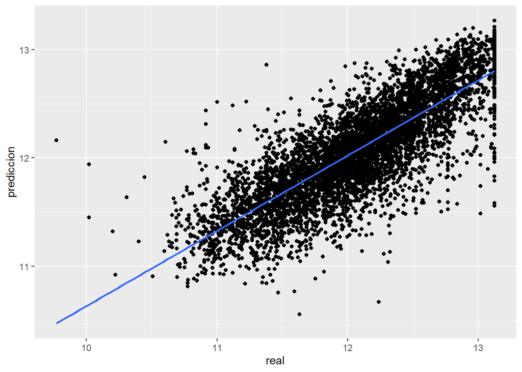

Residuos:

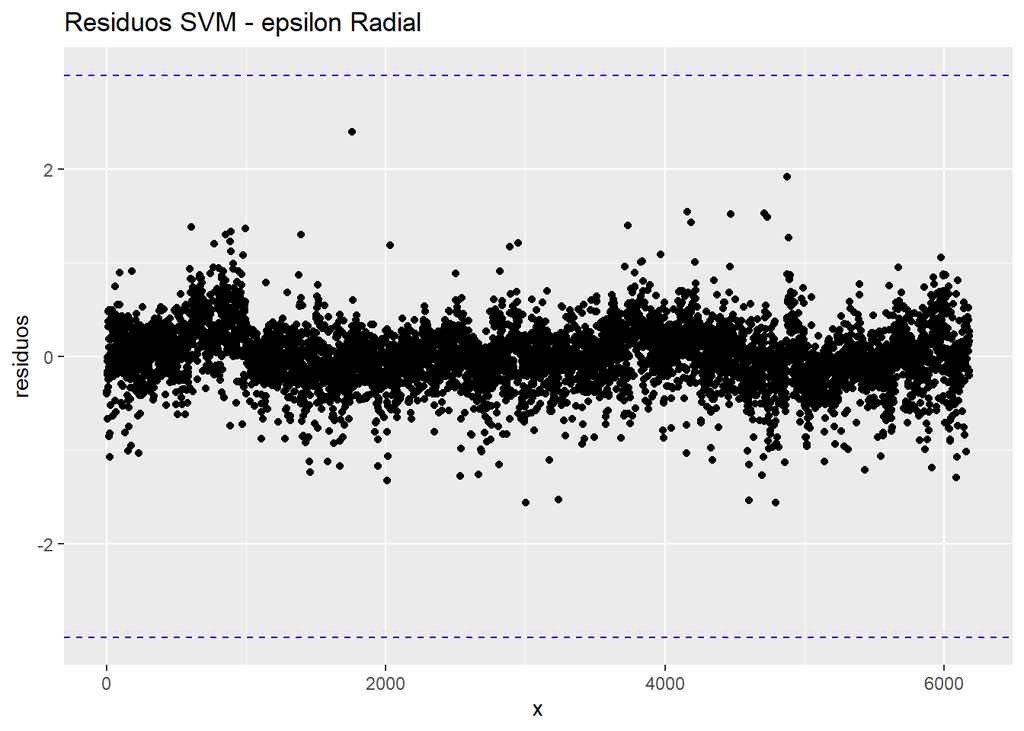

#### 5.3.1.2 Kernel Lineal

Se estima el modelo y luego se realiza la predicción

```
Call:
svm(formula = log_median_house_value ~ ., data = data_train, type = "eps-regression",
    kernel = "linear", trControl = trainControl(method = "cv", number = 10,
        allowParallel = TRUE), tuneGrid = epsilonSVRGrid, metric = "RMSE")


Parameters:
   SVM-Type:  eps-regression
 SVM-Kernel:  linear
       cost:  1
      gamma:  0.12
    epsilon:  0.1


Number of Support Vectors:  12234
```

Gráficamente:

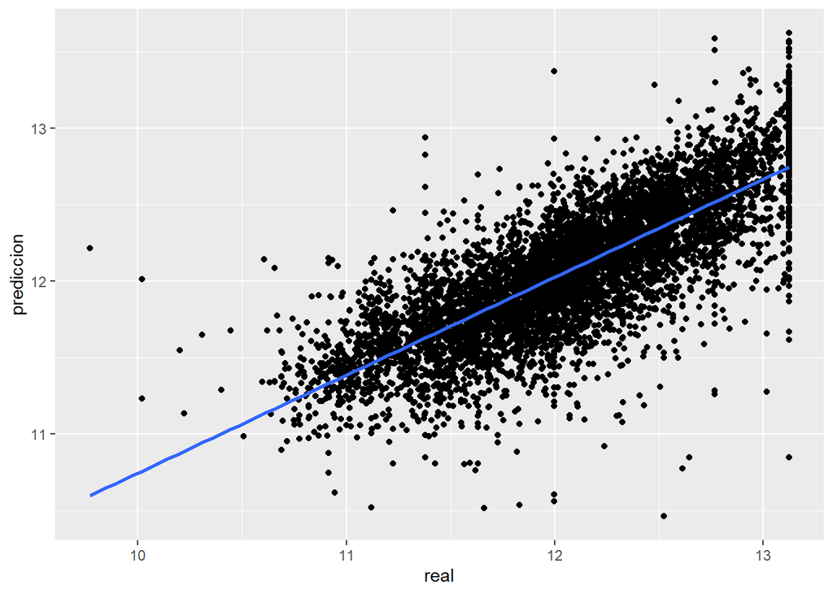

Residuos:

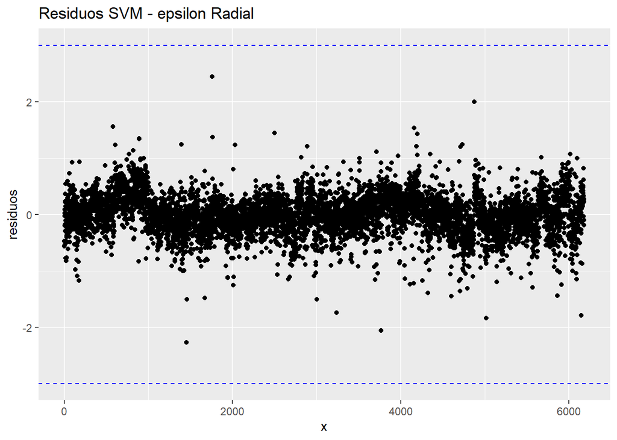

#### 5.3.1.3 Kernel Polinomial

Se estima el modelo y luego se realiza la predicción:

[output not shown]

Gráficamente:

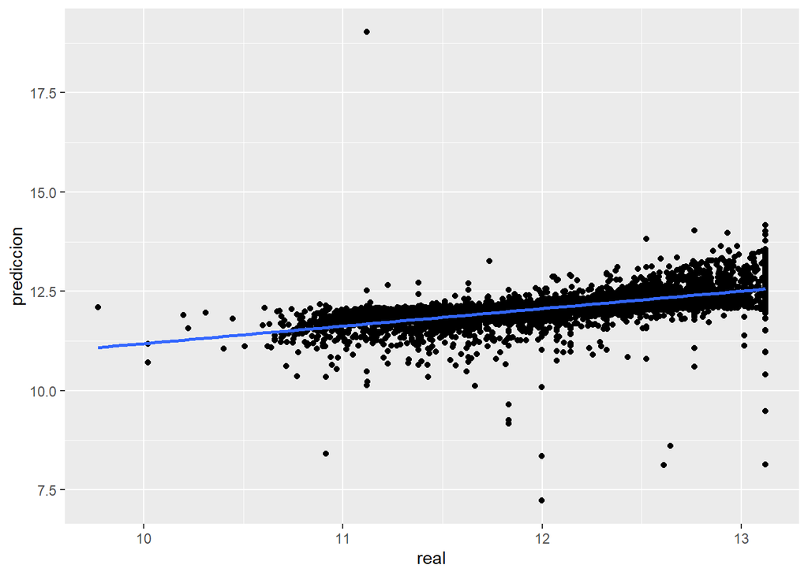

Residuos:

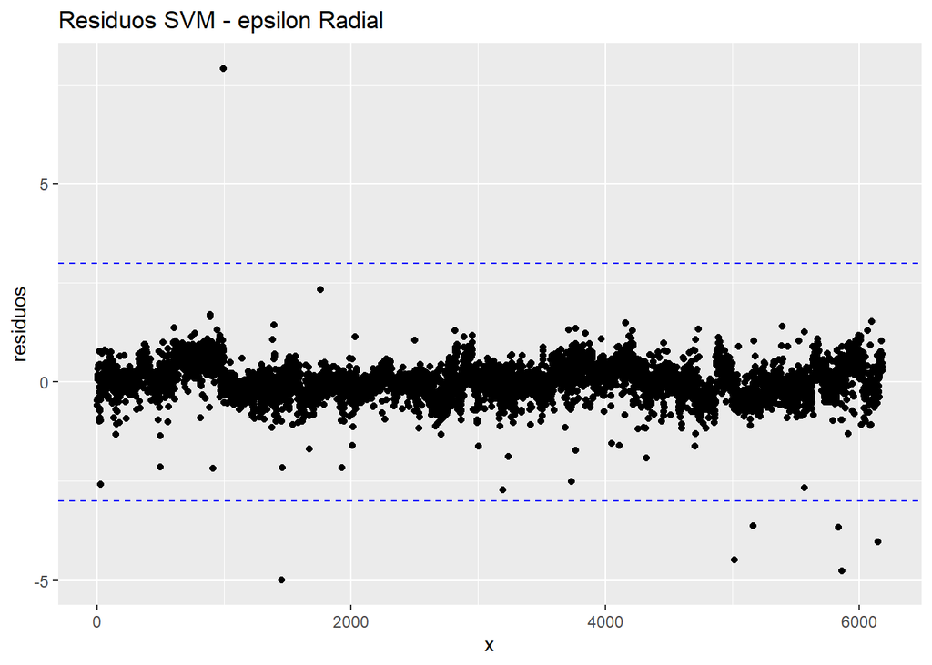

### 5.3.2 Nu - SVR

#### 5.3.2.1 Kernel Radial

Se estima el modelo y luego se realiza la predicción

```
Call:
svm(formula = log_median_house_value ~ ., data = data_train, type = "nu-regression",
    kernel = "radial", trControl = trainControl(method = "cv", number = 10,
        allowParallel = TRUE), tuneGrid = nuSVRGrid, metric = "RMSE")


Parameters:
   SVM-Type:  nu-regression
 SVM-Kernel:  radial
       cost:  1
         nu:  0.5

Number of Support Vectors:  7397
```

Comparando con el modelo SVM - Epsilon, también con kernel radial, se ve claramente que la cantidad de vectores soporte es mucho menor en SVM - Nu: 7.397 versus 11.790. Esto se condice con lo mencionado previamente.

Gráficamente:

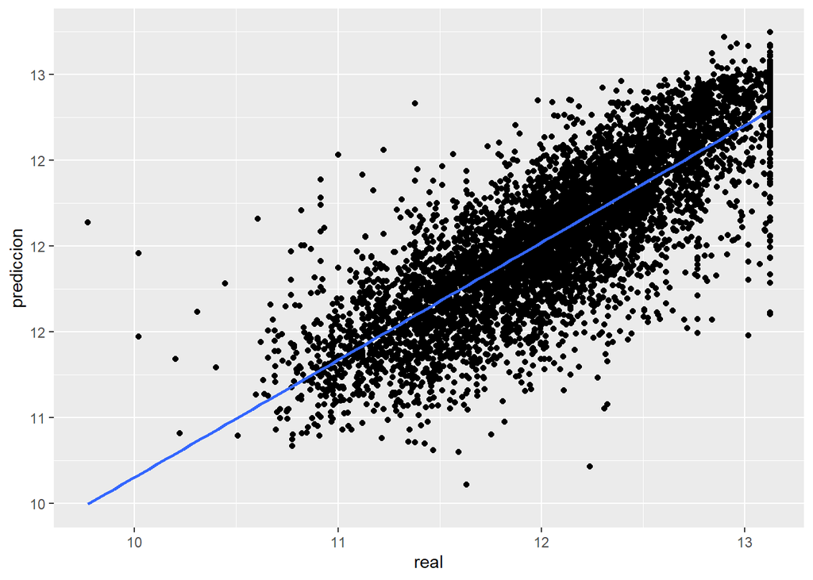

Residuos:

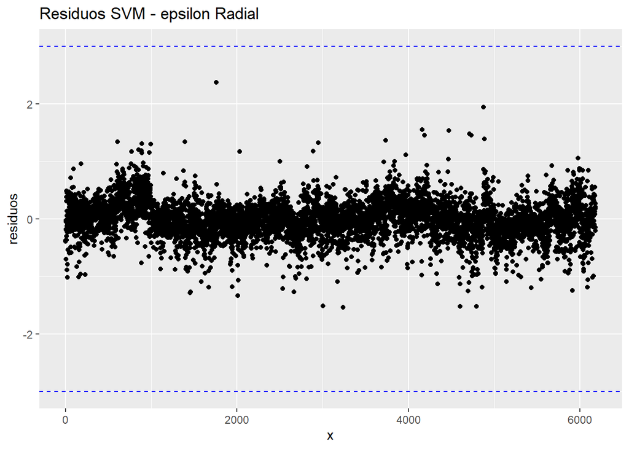

#### 5.3.2.2 Kernel Lineal

Se estima el modelo y luego se realiza la predicción

```
Call:
svm(formula = log_median_house_value ~ ., data = data_train, type = "nu-regression",
    kernel = "linear", trControl = trainControl(method = "cv", number = 10,
        allowParallel = TRUE), tuneGrid = nuSVRGrid, metric = "RMSE")


Parameters:
   SVM-Type:  nu-regression
 SVM-Kernel:  linear
       cost:  1
         nu:  0.5

Number of Support Vectors:  7230
```

Al igual que en el caso anterior, el número de vectores soporte es mucho menor en este modelo que en su equivalente SVM - Epsilon: 7.230 versus 12.234.

Gráficamente:

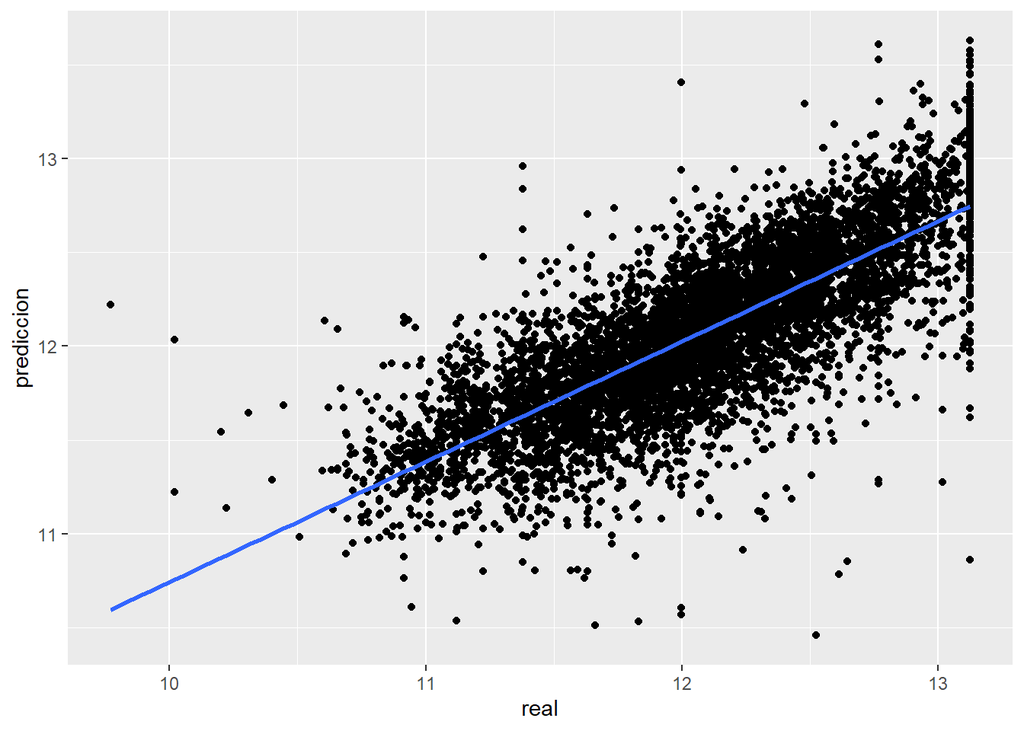

Residuos:

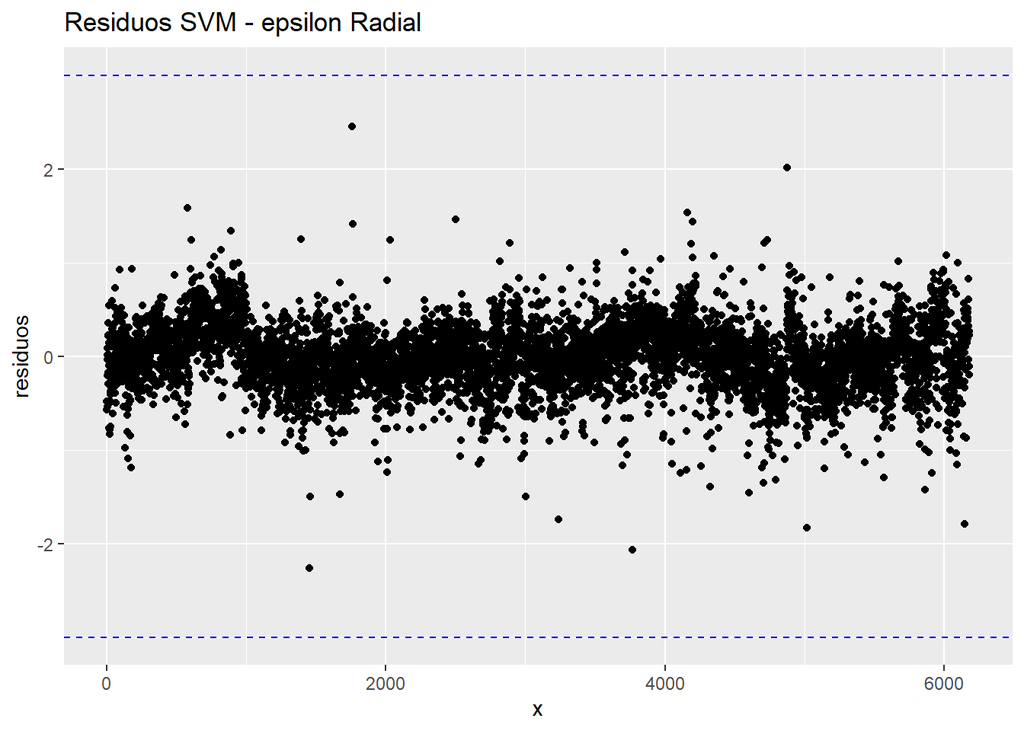

#### 5.3.2.3 Kernel Polinomial

Se estima el modelo y luego se realiza la predicción

```
Call:
svm(formula = log_median_house_value ~ ., data = data_train, type = "nu-regression",
    kernel = "polynomial", trControl = trainControl(method = "cv",
        number = 10, allowParallel = TRUE), tuneGrid = nuSVRGrid_poly,
    metric = "RMSE", maxit = 1000)


Parameters:
   SVM-Type:  nu-regression
 SVM-Kernel:  polynomial
       cost:  1
     degree:  3
     coef.0:  0
         nu:  0.5

Number of Support Vectors:  7259
```

Este modelo no es la excepción con respecto al número de vectores soporte. Comparando contra SVM - Epsilon se tiene 7.259 versus 11.790

Gráficamente:

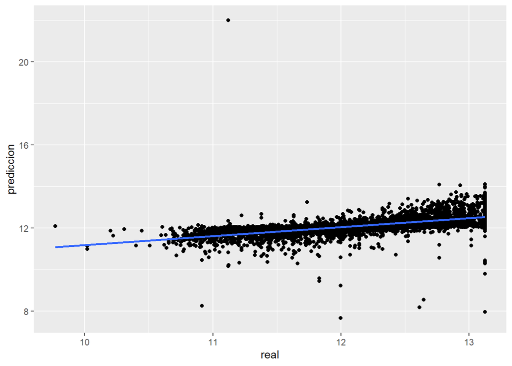

Residuos:

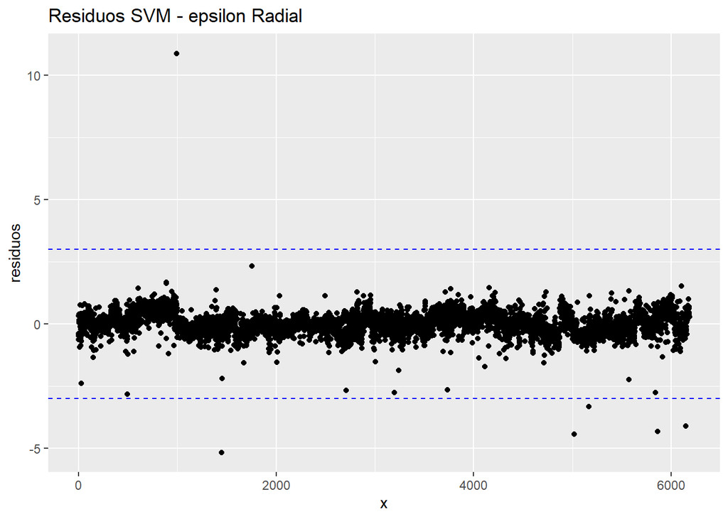

# 6. Resultados y conclusiones

Los resultados obtenidos en cada uno de los modelos son los siguientes:

|  | modelo | datos | RMSE | Rsquared | (Intercept) | median_income | median_income_2 | median_income_3 | log_housing_median_age | log_rooms_pop | log_bedrooms_pop | log_pop_househ | log_households |
| --- | --- | --- | --- | --- | --- | --- | --- | --- | --- | --- | --- | --- | --- |
| Estimate | Regresión lineal | Sin normalizar | 0.36 | 0.60 | 11.52 | 0.49 | -0.02 | 0.00 | 0.15 | -0.87 | 0.82 | -0.40 | 0.04 |
| Estimate1 | Regresión lineal | Normalizados | 0.36 | 0.60 | 11.11 | 7.10 | -4.06 | -0.39 | 0.60 | -8.65 | 8.14 | -2.98 | 0.36 |
| 3 | XG Boost | Sin normalizar | 0.33 | 0.67 | NA | NA | NA | NA | NA | NA | NA | NA | NA |
| 4 | Epsilon SVM - Radial | Sin normalizar | 0.32 | 0.68 | NA | NA | NA | NA | NA | NA | NA | NA | NA |
| 5 | Epsilon SVM - Lineal | Sin normalizar | 0.35 | 0.62 | 0.00 | 1.75 | -0.84 | 0.02 | 0.16 | -0.65 | 0.54 | -0.21 | 0.07 |
| 6 | Epsilon SVM - Polinomial | Sin normalizar | 0.45 | 0.37 | NA | NA | NA | NA | NA | NA | NA | NA | NA |
| 7 | Nu SVM - Radial | Sin normalizar | 0.32 | 0.67 | NA | NA | NA | NA | NA | NA | NA | NA | NA |
| 8 | Nu SVM - Lineal | Sin normalizar | 0.35 | 0.62 | -0.01 | 1.75 | -0.81 | -0.01 | 0.16 | -0.66 | 0.54 | -0.21 | 0.07 |
| 9 | Nu SVM - Polinomial | Sin normalizar | 0.46 | 0.35 | NA | NA | NA | NA | NA | NA | NA | NA | NA |

El RMSE, o error cuadrático medio en castellano (ECM) de un estimador, mide la raíz cuadrática del promedio de los errores al cuadrado, es decir, la diferencia entre el valor estimado o predicho y el valor real u observado. Es una medida de error absoluta que calcula el cuadrado de las desviaciones para evitar que las desviaciones positivsa y negativas se cancelen entre sí. Al darle más peso a los errores grandes, penaliza aquellos métodos con grandes errores.

El R-cuadrado es una medida estadística de qué tan cerca están los datos de la línea de regresión ajustada, represnta el porcentaje de la variación en la variable de respuesta que es explicado por un modelo lineal.

Por otro lado, evaluando el R-cuadrado, el mejor modelo es Epsilon SVM - Radial.

Sin embargo, puede verse que estos dos modelos - Nu SVM - Polinomial y el Epsilon SVM - Radial- tienen el valor más bajo de el Rcuadrado y el RMSE respectivamente.

Se selecciona como mejor modelo el Epsilon SVM - Radial, puesto que tiene un mejor balance entre las dos métricas analizadas.

# 7. Recursos utilizados

https://cran.r-project.org/web/packages/e1071/e1071.pdf

https://www.rdocumentation.org/packages/e1071/versions/1.7-7/topics/svm